# Mapping Obesity: A County-Level Analysis of Lifestyle and Food Environment Factors

Authors

Jordan Faustin

Helen Peng

Anvith Thumma

Published

July 25, 2025

## Introduction

Obesity is a growing public health crisis in the United States contributing to chronic conditions such as type 2 diabetes, heart disease, and certain types of cancer. In addition to its health impacts, obesity places a significant financial strain on the healthcare system, with billions spent annually on treatment and related complications. As the prevalence of obesity continues to rise, there is a growing need to understand the underlying environmental and social drivers that contribute to this epidemic.

While individual behavior plays a role, mounting evidence points to the importance of social determinants of health—such as access to safe spaces for physical activity and availability of nutritious food. These factors are often shaped by the built environment, including infrastructure, economic conditions, and community planning. For example, neighborhoods with few parks or grocery stores may discourage healthy behavior, while environments that support walking, biking, and affordable food access can promote better health outcomes.

This study explores the research question: *Do physical inactivity levels and access to healthy food affect obesity rates at the county level?* By focusing on these two predictors, the goal is to investigate how variations in community resources and infrastructure may influence the health of populations across different regions. Understanding these relationships is critical for informing public health interventions, designing equitable urban policies, and creating targeted wellness programs in schools, workplaces, and communities.

## Data

We used publicly available county-level data from the **2025 County Health Rankings Data**, provided by the University of Wisconsin Population Health Institute. The dataset includes a wide range of health-related indicators across all U.S. counties, including demographics, socioeconomic, behavioral, and healthcare access variables.

Our main variables of interests were:

- **Adults with Obesity (%):** Percentage of adults (18+) with a body mass index (BMI) ≥ 30 kg/m² (age-adjusted).
- **Physical Inactivity (%):** Percentage of adults (18+) reporting no leisure-time physical activity (age-adjusted).
- **(FEI) Food Environment Index (1-10):** Composite score indicating community access to healthy food and income levels.
- **Limited Access to Healthy Food (%):** Percentage of the population that is low income and does not live close to a grocery store

For missing data, we imputed missing predictor values using the state average. Counties missing data for the response variable (adults with obesity) were excluded from the analysis (a total of 7 counties), resulting in a complete case dataset.

### Exploratory Data Analysis

We began our exploratory analysis by visualizing the geographic distribution of adult obesity rates across the United States.

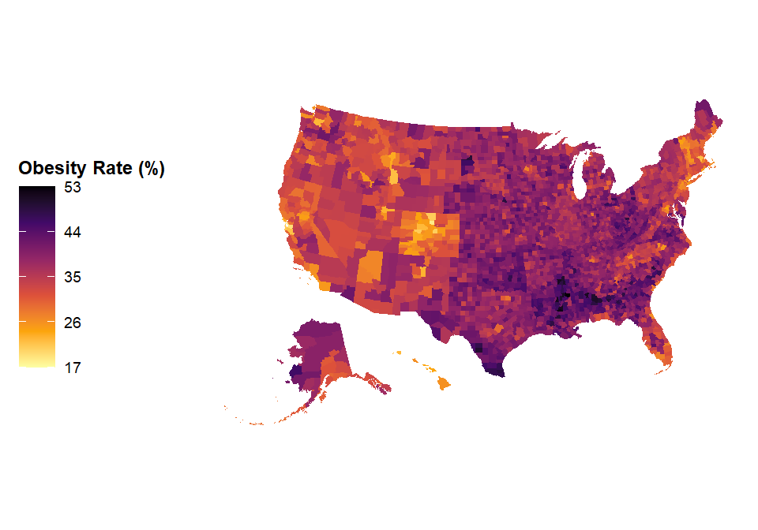

Figure 2: Choropleth map showing substantial regional variation in adult obesity rates across U.S. counties in 2025.

From the map, we observe that obesity rates are generally higher in the Southern states and parts of the Midwest, whereas lower rates tend to be concentrated in the Western and Northeastern regions. This pattern suggests potential regional influences such as socioeconomic conditions, healthcare access, or cultural norms that may contribute to differences in obesity prevalence.

Next, we examined how obesity rates relate to key predictor variables through a series of scatter plots.

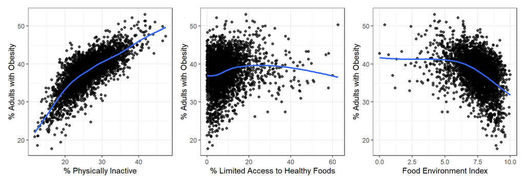

Figure 1: Scatter plots illustrating the relationship between predictor variables and obesity rates.

These scatter plots reveal a positive association between physical inactivity and obesity rates, indicating that counties with higher levels of inactivity tend to have higher obesity prevalence. In contrast, limited access to healthy food shows no clear association with obesity rates. Meanwhile, Food Environment Index (FEI) shows a negative association, suggesting that counties with more favorable food environments tend to have lower obesity rates.

To further examine the relationships among our predictor variables, we created a correlation matrix.

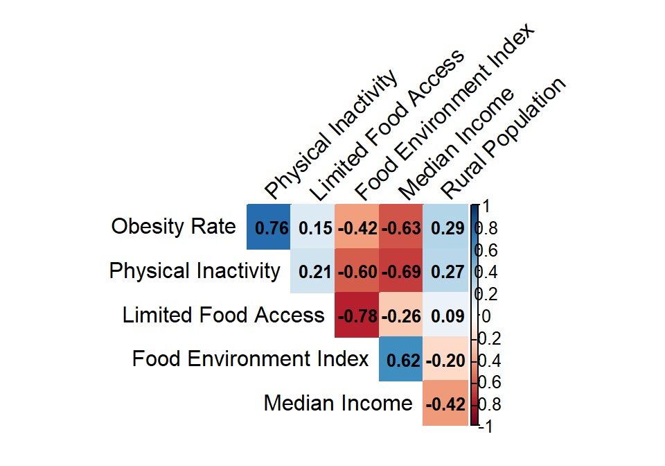

Figure 3: Correlation matrix showing relationships among obesity rate, physical inactivity, food access measures, income, and rural population.

## Methods

Based on our exploratory data analysis, we found that the Food Environment Index (FEI) was a more comprehensive predictor than the percentage of limited access to healthy food, and thus selected it for modeling. Our response variable, adult obesity rate, was originally expressed as a percentage. We first re-scaled it to a proportion between 0 and 1, denoted as $p$, and then applied the logit transformation:

$$\text{logit}(p) = \log\left(\frac{p}{1 - p}\right)$$

This transformation ensured the outcome variable was unbounded, which better satisfies the linearity assumption of regression models.

We initially fit a multiple linear regression model:

$$\text{logit}(\text{Obesity Rate}) = \beta_0 + \beta_1 \cdot \text{Physical Inactivity} + \beta_2 \cdot \text{Food Environment Index} + \varepsilon$$

A linear regression model assumes linearity, constant variance (homoscedasticity), independence of observations, and normally distributed residuals. However, our diagnostic analysis revealed violations of these assumptions, notably due to about 200 influential outliers identified, using the standard Cook’s Distance threshold ($D_i > \frac{4}{n}$), which would negatively affect the model fit. To address this, we refit the model using Huber regression, a robust technique that reduces the influence of outliers.

To further evaluate the predictive utility of our selected variables, we refit the same model using limited access to healthy food in place of the Food Environment Index. This second model allowed us to directly compare the two predictors and reinforce the conclusion that FEI may offer a stronger and more comprehensive explanation of obesity variation across counties.

## Results

The estimated odds ratios and their confidence intervals for both models are displayed in the plot below, followed by an interpretation of the main findings.

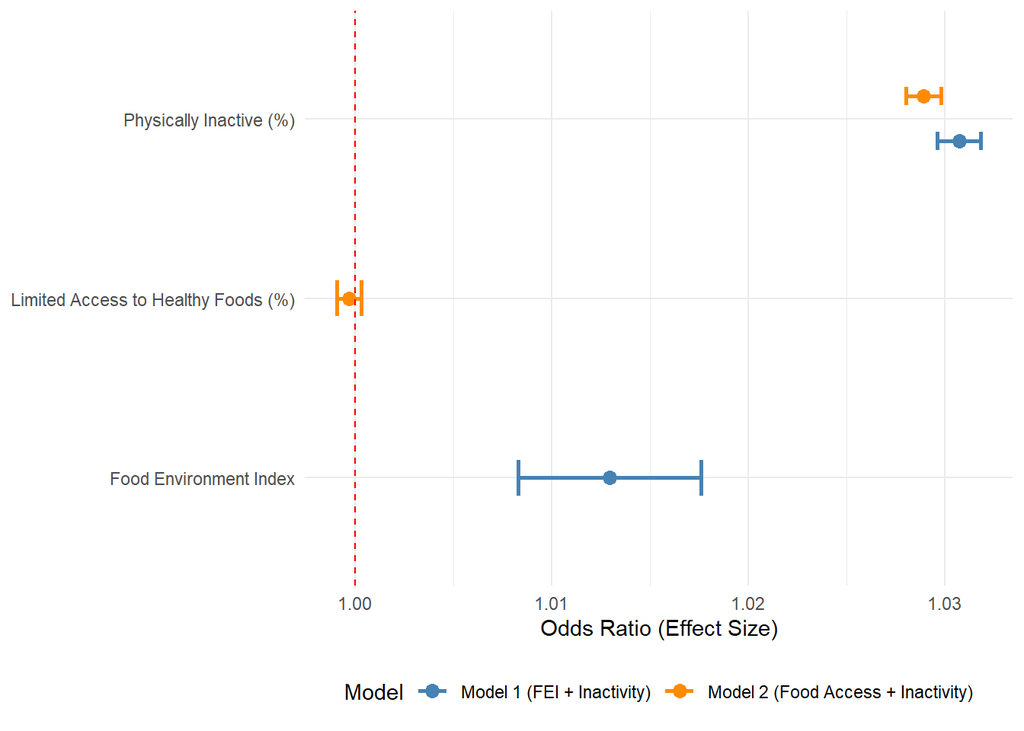

The positive association between FEI and obesity is somewhat counterintuitive, as our exploratory analysis suggested a negative relationship. One possible explanation is that when physical inactivity is held constant, the benefits of food access, such as walking to nearby stores or choosing healthier options, may no longer influence obesity rates, since those behaviors are effectively accounted for in the model. Additionally, the positive coefficient for FEI may reflect confounding factors not captured in our model, such as urbanization or broader socioeconomic conditions that simultaneously influence food environment scores and obesity prevalence.

In **Model 2**, which includes physical inactivity and limited access to healthy food as predictors, physical inactivity remains statistically significant (*t* = 63.9), while limited access is not (*t* = –0.97). A 1% increase in physical inactivity is associated with approximately a **2.9% increase in the odds** of adult obesity, holding limited access constant.

Across both models, **physical inactivity consistently emerges as a strong and robust predictor** of adult obesity, with a larger effect size than either FEI or limited food access. This highlights the critical role of physical activity in shaping obesity outcomes and supports its prioritization in public health interventions.

### Model Evaluation

To compare the two models, we evaluated several performance metrics including R-squared, AIC, BIC, and mean absolute error (MAE). These metrics help determine which model better captures the relationship between the predictors and adult obesity rates.

| Model | R² | AIC | BIC | MAE |
| --- | --- | --- | --- | --- |
| FEI + Inactivity | 0.576 | -3,804.504 | -3,780.227 | 0.101 |
| Food Access + Inactivity | 0.581 | -3,741.435 | -3,717.213 | 0.102 |

While the model including limited access to healthy food and physical inactivity shows a slightly higher R² value, indicating it explains marginally more variance in obesity rates, the model with the Food Environment Index (FEI) performs better on other important criteria. Specifically, the FEI model has lower AIC and BIC values, suggesting it achieves a better balance between model fit and complexity. Additionally, the FEI model has a marginally lower MAE, indicating slightly more accurate predictions on average.

Taken together, these results suggest that the model including FEI provides a more parsimonious and robust fit to the data, making it the preferable choice despite the slightly lower R². This supports the use of FEI as a more comprehensive measure of the food environment’s impact on obesity rates.

## Recommendations

**Prioritize Physical Activity Infrastructure**

Investing in infrastructure that promotes physical activity is essential for reducing obesity rates, particularly in counties with high levels of physical inactivity. Creating walkable communities by expanding sidewalks, bike lanes, and trails makes active transportation more accessible and safe. A notable example is the *Minneapolis Complete Streets Policy*, which prioritizes pedestrians, bicyclists, and transit users in street design. This initiative has led to increased biking and walking while supporting safer and more equitable access to physical activity. Similar models could be adopted in high-obesity counties across the Midwest and South, where urban sprawl often limits pedestrian infrastructure. Additionally, increasing investment in *Safe Routes to School* programs can further support active lifestyles by improving crosswalks, signage, and sidewalk conditions near schools, helping children build habits of daily activity.

**Improve Food Access with Targeted Interventions**

Food access remains a major barrier in many rural and low-income urban counties, particularly across the South and Midwest. Mobile food solutions, such as *Veggie Van* in North Carolina and *Fresh Moves Mobile Market* in Chicago, have proven successful in delivering fresh produce to communities with limited access to grocery stores. These services often pair produce sales with cooking demonstrations or nutrition workshops, making healthy eating more accessible and culturally relevant. Pop-up farmers markets held at schools, churches, and community centers can further bridge food gaps, especially when coordinated with local public health departments or nonprofit organizations. These strategies are flexible, community-driven, and can be scaled or adapted based on local needs and food availability.

**Redirect Funding to Hyper-Local Initiatives**

While broad indicators like the Food Environment Index (FEI) are useful for identifying trends, targeted, hyper-local strategies often yield greater impact. Redirecting funding from large-scale programs to smaller, community-embedded efforts can better address the specific needs of a neighborhood or county. For example, in Louisville, Kentucky, the *Fresh Stop Markets* program partners with local farmers to provide subsidized CSA (Community Supported Agriculture) boxes to low-income residents, improving access to fresh produce while supporting regional agriculture. Such programs offer more tailored support than generic interventions, allowing communities to engage directly in both the design and implementation of solutions. This approach ensures that resources are used where they are most needed, with maximum relevance and efficiency.

## Discussion

### Future Work

To build on these findings, several avenues for future research are recommended. First, incorporating data on the number of parks, wellness centers, and recreational facilities per county—and mapping their distribution—can help clarify the role of environmental supports for physical activity. Additionally, analyzing temporal trends in fitness facility usage may offer insights into behavioral patterns and access disparities. Future studies should also explore other relevant variables that could influence obesity, such as public transportation availability, climate, and healthcare access. Finally, applying causal inference methods, such as instrumental variable analysis or matching methods, could help determine whether physical inactivity actually causes obesity, as current results are based on observed correlations and cannot confirm causation.

## Appendix

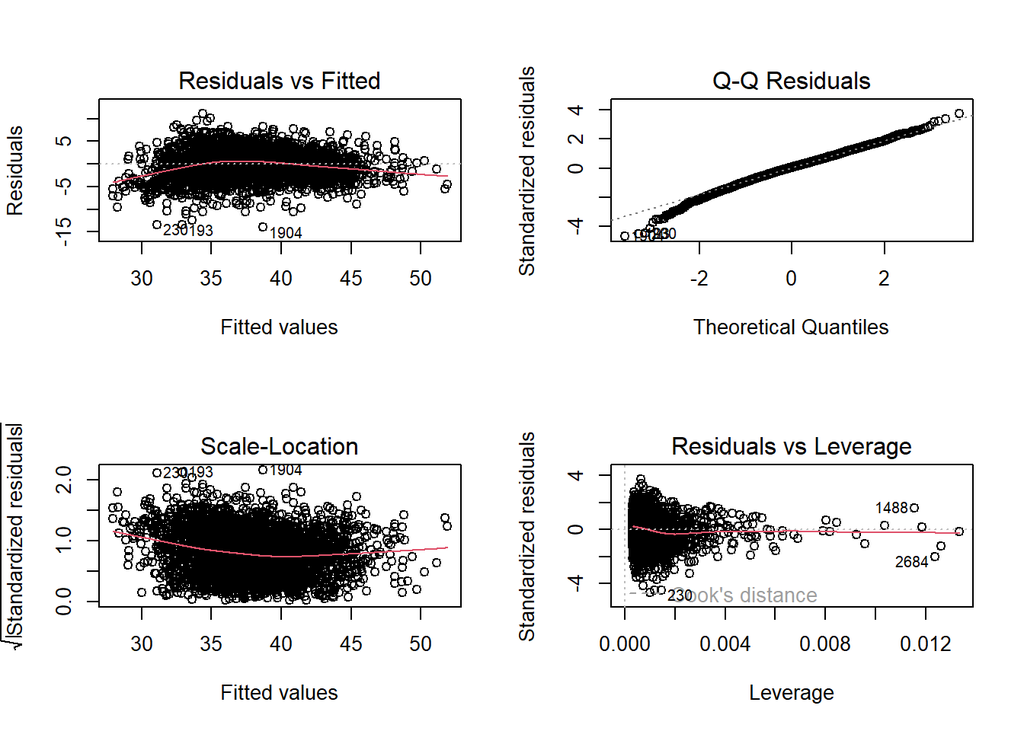

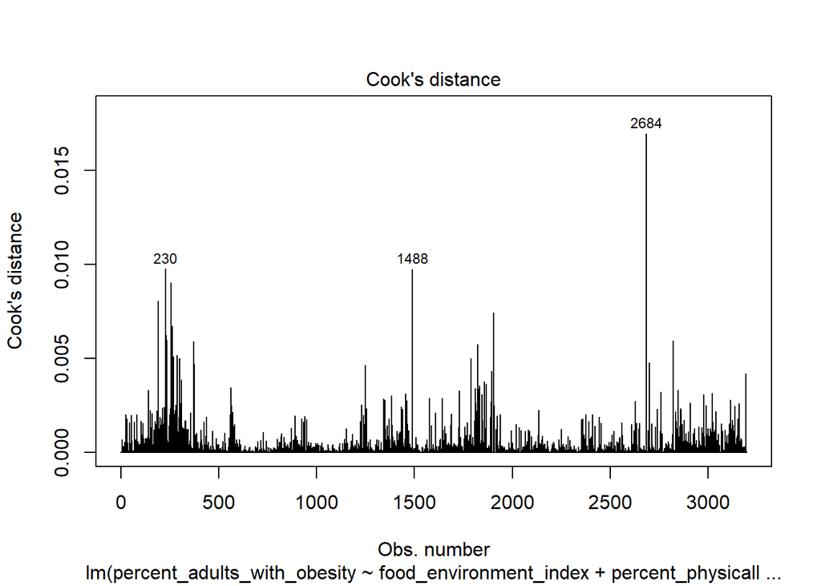

FEI + Inactivity

| term | estimate | std.error | statistic | conf.low | conf.high | OR | OR_low | OR_high |
| --- | --- | --- | --- | --- | --- | --- | --- | --- |
| Food Environment Index | 0.013 | 0.002 | 5.497 | 0.008 | 0.017 | 1.013 | 1.008 | 1.018 |
| Physically Inactive (%) | 0.030 | 0.001 | 56.015 | 0.029 | 0.031 | 1.031 | 1.030 | 1.032 |

Food Access + Inactivity

| term | estimate | std.error | statistic | conf.low | conf.high | OR | OR_low | OR_high |
| --- | --- | --- | --- | --- | --- | --- | --- | --- |
| Physically Inactive (%) | 0.029 | 0 | 63.873 | 0.028 | 0.029 | 1.029 | 1.028 | 1.03 |
| Limited Access to Healthy Foods (%) | 0.000 | 0 | -0.975 | -0.001 | 0.000 | 1.000 | 0.999 | 1.00 |